# EDA Avito

LegenDad

2018-06-06

# 1 Introduction

[figure not shown]

From Description Page

> In their fourth Kaggle competition, Avito is challenging you to predict demand for an online advertisement based on its full description (title, description, images, etc.), its context (geographically where it was posted, similar ads already posted) and historical demand for similar ads in similar contexts. With this information, Avito can inform sellers on how to best optimize their listing and provide some indication of how much interest they should realistically expect to receive.

18 Variables

> - item_id - Ad id.
> - user_id - User id.
> - region - Ad region.
> - city - Ad city.
> - parent_category_name - Top level ad category as classified by Avito’s ad model.
> - category_name - Fine grain ad category as classified by Avito’s ad model.
> - param_1 - Optional parameter from Avito’s ad model.
> - param_2 - Optional parameter from Avito’s ad model.
> - param_3 - Optional parameter from Avito’s ad model.
> - title - Ad title.
> - description - Ad description.
> - price - Ad price.
> - item_seq_number - Ad sequential number for user.
> - activation_date- Date ad was placed.
> - user_type - User type.
> - image - Id code of image. Ties to a jpg file in train_jpg. Not every ad has an image.
> - image_top_1 - Avito’s classification code for the image.
> - deal_probability - The target variable. This is the likelihood that an ad actually sold something. It’s not possible to verify every transaction with certainty, so this column’s value can be any float from zero to one.

# 2 Library & Importing

## 2.1 Loading Library

```r
library(tidyverse)
library(knitr)
library(skimr)
library(DT)
library(ggthemes)
library(lubridate)
```

## 2.2 Importing Data

```r
avi <- read_csv("../input/train.csv")
avite <- read_csv("../input/test.csv")
```

# 3 Glimpse of Data

## 3.1 Glimpse of train

```r
glimpse(avi)
```

```
## Observations: 1,503,424
## Variables: 18
## $ item_id              <chr> "b912c3c6a6ad", "2dac0150717d", "ba83aefa...
## $ user_id              <chr> "e00f8ff2eaf9", "39aeb48f0017", "91e2f88d...
## $ region               <chr> "Свердловская область", "Самарская област...
## $ city                 <chr> "Екатеринбург", "Самара", "Ростов-на-Дону...
## $ parent_category_name <chr> "Личные вещи", "Для дома и дачи", "Бытова...
## $ category_name        <chr> "Товары для детей и игрушки", "Мебель и и...
## $ param_1              <chr> "Постельные принадлежности", "Другое", "В...
## $ param_2              <chr> NA, NA, NA, NA, "ВАЗ (LADA)", NA, NA, "Дж...
## $ param_3              <chr> NA, NA, NA, NA, "2110", NA, NA, "26", "> ...
## $ title                <chr> "Кокоби(кокон для сна)", "Стойка для Одеж...
## $ description          <chr> "Кокон для сна малыша,пользовались меньше...
## $ price                <dbl> 400, 3000, 4000, 2200, 40000, 1300, 11000...
## $ item_seq_number      <int> 2, 19, 9, 286, 3, 9, 125, 61, 85, 136, 6,...
## $ activation_date      <date> 2017-03-28, 2017-03-26, 2017-03-20, 2017...
## $ user_type            <chr> "Private", "Private", "Private", "Company...
## $ image                <chr> "d10c7e016e03247a3bf2d13348fe959fe6f436c1...
## $ image_top_1          <dbl> 1008, 692, 3032, 796, 2264, 796, 2823, 56...
## $ deal_probability     <dbl> 0.12789, 0.00000, 0.43177, 0.80323, 0.207...
```

## 3.2 Summary of train

```r
summary(avi)
```

```
##    item_id            user_id             region
##  Length:1503424     Length:1503424     Length:1503424
##  Class :character   Class :character   Class :character
##  Mode  :character   Mode  :character   Mode  :character
##
##
##
##
##      city           parent_category_name category_name
##  Length:1503424     Length:1503424       Length:1503424
##  Class :character   Class :character     Class :character
##  Mode  :character   Mode  :character     Mode  :character
##
##
##
##
##    param_1            param_2            param_3
##  Length:1503424     Length:1503424     Length:1503424
##  Class :character   Class :character   Class :character
##  Mode  :character   Mode  :character   Mode  :character
##
##
##
##
##     title           description            price
##  Length:1503424     Length:1503424     Min.   :0.000e+00
##  Class :character   Class :character   1st Qu.:5.000e+02
##  Mode  :character   Mode  :character   Median :1.300e+03
##                                        Mean   :3.167e+05
##                                        3rd Qu.:7.000e+03
##                                        Max.   :7.950e+10
##                                        NA's   :85362
##  item_seq_number    activation_date       user_type
##  Min.   :     1.0   Min.   :2017-03-15   Length:1503424
##  1st Qu.:     9.0   1st Qu.:2017-03-18   Class :character
##  Median :    29.0   Median :2017-03-22   Mode  :character
##  Mean   :   743.7   Mean   :2017-03-21
##  3rd Qu.:    88.0   3rd Qu.:2017-03-25
##  Max.   :204429.0   Max.   :2017-04-07
##
##     image            image_top_1     deal_probability
##  Length:1503424     Min.   :   0     Min.   :0.0000
##  Class :character   1st Qu.: 425     1st Qu.:0.0000
##  Mode  :character   Median :1057     Median :0.0000
##                     Mean   :1242     Mean   :0.1391
##                     3rd Qu.:2217     3rd Qu.:0.1509
##                     Max.   :3066     Max.   :1.0000
##                     NA's   :112588
```

## 3.3 Summary of test

```r
summary(avite)
```

```
##    item_id            user_id             region
##  Length:508438      Length:508438      Length:508438
##  Class :character   Class :character   Class :character
##  Mode  :character   Mode  :character   Mode  :character
##
##
##
##
##      city           parent_category_name category_name
##  Length:508438      Length:508438        Length:508438
##  Class :character   Class :character     Class :character
##  Mode  :character   Mode  :character     Mode  :character
##
##
##
##
##    param_1            param_2            param_3
##  Length:508438      Length:508438      Length:508438
##  Class :character   Class :character   Class :character
##  Mode  :character   Mode  :character   Mode  :character
##
##
##
##
##     title           description            price
##  Length:508438      Length:508438      Min.   :0.000e+00
##  Class :character   Class :character   1st Qu.:5.000e+02
##  Mode  :character   Mode  :character   Median :1.500e+03
##                                        Mean   :2.798e+05
##                                        3rd Qu.:8.600e+03
##                                        Max.   :3.000e+09
##                                        NA's   :30585
##  item_seq_number    activation_date       user_type
##  Min.   :     1.0   Min.   :2017-04-12   Length:508438
##  1st Qu.:     8.0   1st Qu.:2017-04-13   Class :character
##  Median :    30.0   Median :2017-04-15   Mode  :character
##  Mean   :   825.1   Mean   :2017-04-14
##  3rd Qu.:    94.0   3rd Qu.:2017-04-17
##  Max.   :205064.0   Max.   :2017-04-20
##
##     image            image_top_1
##  Length:508438      Min.   :   0
##  Class :character   1st Qu.: 467
##  Mode  :character   Median :1132
##                     Mean   :1298
##                     3rd Qu.:2218
##                     Max.   :3066
##                     NA's   :42609
```

# 4 LookUp & NA

## 4.1 Head train

```r
head(avi, 50) %>% datatable(filter = 'top',
                            options = list(pageLength = 10, autoWidth = T))
```

|  | item_id | user_id | region | city | parent_category_name | category_name | param_1 | param_2 | param_3 | title | description | price | item_seq_number | activation_date | user_type | image | image_top_1 | deal_probability |
| --- | --- | --- | --- | --- | --- | --- | --- | --- | --- | --- | --- | --- | --- | --- | --- | --- | --- | --- |
| 1 | b912c3c6a6ad | e00f8ff2eaf9 | Свердловская область | Екатеринбург | Личные вещи | Товары для детей и игрушки | Постельные принадлежности |  |  | Кокоби(кокон для сна) | Кокон для сна малыша,пользовались меньше месяца.цвет серый | 400 | 2 | 2017-03-28 | Private | d10c7e016e03247a3bf2d13348fe959fe6f436c1caf64c7679f17c333c959b19 | 1008 | 0.12789 |
| 2 | 2dac0150717d | 39aeb48f0017 | Самарская область | Самара | Для дома и дачи | Мебель и интерьер | Другое |  |  | Стойка для Одежды | Стойка для одежды, под вешалки. С бутика. | 3000 | 19 | 2017-03-26 | Private | 79c9392cc51a9c81c6eb91eceb8e552171db39d71427001e1e0859c0fb843a31 | 692 | 0 |
| 3 | ba83aefab5dc | 91e2f88dd6e3 | Ростовская область | Ростов-на-Дону | Бытовая электроника | Аудио и видео | Видео, DVD и Blu-ray плееры |  |  | Philips bluray | В хорошем состоянии, домашний кинотеатр с blu ray, USB. Если настроить, то работает смарт тв / Торг | 4000 | 9 | 2017-03-20 | Private | b7f250ee3f39e1fedd77c141f273703f4a9be59db4b48a8713f112c67e29bb42 | 3032 | 0.43177 |
| 4 | 02996f1dd2ea | bf5cccea572d | Татарстан | Набережные Челны | Личные вещи | Товары для детей и игрушки | Автомобильные кресла |  |  | Автокресло | Продам кресло от0-25кг | 2200 | 286 | 2017-03-25 | Company | e6ef97e0725637ea84e3d203e82dadb43ed3cc0a1c841302bf49820803501b4b | 796 | 0.80323 |
| 5 | 7c90be56d2ab | ef50846afc0b | Волгоградская область | Волгоград | Транспорт | Автомобили | С пробегом | ВАЗ (LADA) | 2110 | ВАЗ 2110, 2003 | Все вопросы по телефону. | 40000 | 3 | 2017-03-16 | Private | 54a687a3a0fc1d68aed99bdaaf551c5c70b761b16fd0a2c089d8376e883ed33b | 2264 | 0.20797 |
| 6 | 51e0962387f7 | bbfad0b1ad0a | Татарстан | Чистополь | Личные вещи | Товары для детей и игрушки | Автомобильные кресла |  |  | Авто люлька | В хорошем состоянии | 1300 | 9 | 2017-03-28 | Private | eb6ad1231c59d3dc7e4020e724ffe8e4d302023ddcbb99c52a6117994dd44690 | 796 | 0.80323 |
| 7 | c4f260a2b48a | 08f469d2e6f7 | Нижегородская область | Нижний Новгород | Для дома и дачи | Ремонт и строительство | Сантехника и сауна |  |  | Водонагреватель 100 литров нержавейка плоский | Электро водонагреватель накопительный на 100 литров Термекс ID 100V, плоский, внутренний бак из нержавейки, 2 кВт, б/у 2 недели, на гарантии. | 11000 | 125 | 2017-03-23 | Private | 0330f6ac561f5db1fa8226dd5e7e127b5671d44d075a9801ec9e6ee9d20ad2c6 | 2823 | 0 |
| 8 | 6b71309d6a8a | fef86baa002c | Пермский край | Пермь | Личные вещи | Одежда, обувь, аксессуары | Женская одежда | Джинсы | 26 | Бойфренды colins | Бойфренды в хорошем состоянии. | 500 | 61 | 2017-03-25 | Private | 9bab29a519e81c14f4582024adfebd4f11a4ac71d323a62f7731e19db9702115 | 567 | 0.80323 |
| 9 | c5b969cb63a2 | 055825270190 | Оренбургская область | Оренбург | Личные вещи | Одежда, обувь, аксессуары | Женская одежда | Платья и юбки | &gt; 50 (XXL) | Платье | 54 раз мер очень удобное | 500 | 85 | 2017-03-17 | Private | 75ce06d1f939a31dfb2af8ac55f08fa998fa336d13ee05326eb44166d47a8aed | 415 | 0 |
| 10 | b1570962e68c | f9e8f831d94c | Нижегородская область | Нижний Новгород | Личные вещи | Детская одежда и обувь | Для девочек | Обувь | 25 | Полу ботиночки замш натур.Бамбини | По стельке 15.5см мерить приокский район. Цвет темнее чем на фото | 400 | 136 | 2017-03-22 | Company | 54fb8521135fda77a860bfd2fac6bf46867ab7c06796e3e3636587c101e10301 | 46 | 0 |

[output cut: 40 more lines]

## 4.2 Head test

```r
head(avite, 50) %>% datatable(filter = 'top',
                            options = list(pageLength = 10, autoWidth = T))
```

|  | item_id | user_id | region | city | parent_category_name | category_name | param_1 | param_2 | param_3 | title | description | price | item_seq_number | activation_date | user_type | image | image_top_1 |
| --- | --- | --- | --- | --- | --- | --- | --- | --- | --- | --- | --- | --- | --- | --- | --- | --- | --- |
| 1 | 6544e41a8817 | dbe73ad6e4b5 | Волгоградская область | Волгоград | Личные вещи | Детская одежда и обувь | Для мальчиков | Обувь | 25 | Отдам бесплатно | На ангарском |  | 66 | 2017-04-18 | Private | a8b57acb5ab304f9c331ac7a074219aed4d349d8aef386bd5e32262735e68512 | 2020 |
| 2 | 65b9484d670f | 2e11806abe57 | Свердловская область | Нижняя Тура | Хобби и отдых | Велосипеды | Дорожные |  |  | Продам велосипед | Продам велосипед KAMA F200,в нормальном состоянии.Все вопросы по телефону.торг уместен. | 3000 | 4 | 2017-04-16 | Private |  |  |
| 3 | 8bab230b2ecd | 0b850bbebb10 | Новосибирская область | Бердск | Бытовая электроника | Аудио и видео | Телевизоры и проекторы |  |  | BBK | Продам новый телевизор BBK 32 диагональ смарт ТВ Wi-Fi приложения на базе андроида продаю в связи с покупкой более большего размера | 15000 | 15 | 2017-04-17 | Private | 8c361112cb049745ef2d1b0ae73594fc5c107286b0c9428bf86da6d04eb6b7d5 | 2960 |
| 4 | 8e348601fefc | 5f1d5c3ce0da | Саратовская область | Саратов | Для дома и дачи | Бытовая техника | Для кухни | Вытяжки |  | Вытяжка Jetair 60 | Продам новую вытяжку в упаковке,с документами.Модель Jetair Tina p60 inx, серебристого цвета. | 4500 | 70 | 2017-04-17 | Private |  |  |
| 5 | 8bd2fe400b89 | 23e2d97bfc7f | Оренбургская область | Бузулук | Личные вещи | Товары для детей и игрушки | Детские коляски |  |  | Коляска зима-лето | Продам отличную коляску. б/у 1 год. все вопросы по телефону. | 4900 | 15 | 2017-04-15 | Private | bc3cf6deef10840fc302e38eb48fa7748aa1e28d534f8fd15f8183be44dc701c | 1002 |
| 6 | c63dbd6c657f | c2a632af2602 | Ростовская область | Ростов-на-Дону | Для дома и дачи | Ремонт и строительство | Окна и балконы |  |  | Стекла для пластиковых окон | Продаю стеклопакеты новые:/ 1. 1322х652х24 / 2. 1178х427х24/ 3. 1175х745х24/ 4. 1097х648х24/ 5. 615х1420х24/ 6. 730х1118х24/ 7. 1193х743х24/ 8. 1138х628х24/ 9. 1183х708х24/ 10. 758х1158х24/ 11. 1198х6… | 500 | 39 | 2017-04-12 | Private | 7acdde494d48f4e46c8be158d64ad73a61d153b825c378abc5368428b365f155 | 1409 |
| 7 | 6d1a410df86e | b239811ad530 | Оренбургская область | Оренбург | Бытовая электроника | Ноутбуки |  |  |  | Ноутбук Lenovo Ideapad 300-15Ibr арт.14899 | Описание: / Ноутбук Lenovo IdeaPad 300-15IBR может похвастаться своей высокопроизводительной аппаратной частью, основа которой представлена 4-ядерным процессором Intel Pentium N3710, функционирующим н… | 20990 | 57316 | 2017-04-17 | Shop | f52abf9f68eca4aac35ed2b67bf093095950c417c080dd7fe575be24dc1e8fde | 2961 |
| 8 | e8d3e7922b80 | d85fa02e6341 | Калининградская область | Калининград | Бытовая электроника | Телефоны | Аксессуары | Чехлы и плёнки |  | Nillkin Phenom для Apple iPhone | Для iPhone 7 (черный)/ / Продаются от магазина "39 Смартфонов". С гарантией и документами./ / Мы находимся по адресу: Советский проспект 6А ТЦ "Северный" 3 этаж. (ориентир McDonalds на Советском)/ / О… | 990 | 851 | 2017-04-18 | Shop | 2e2b5526345f5d66571615dd0fdc984f765a336ec6df3d70447769c4a653062b | 2909 |
| 9 | 2bc1ab208462 | ae6586719bec | Новосибирская область | Новосибирск | Бытовая электроника | Товары для компьютера | Флэшки и карты памяти |  |  | Флешка USB 32Gb smartbuy | новые/ / есть синие и оранжевые/ / SmartBuy Paean 32GB обладает стильным дизайном. Классическая конструкция флешки оборудована защитным колпачком для предотвращения повреждений устройства. Также преду… | 1200 | 10020 | 2017-04-18 | Company | 8aa1dfcbdc489750eb965e43ff545505f2c845990d73f9a7b8022d7ec0c0d417 | 2815 |
| 10 | 7e05d77a9181 | 30ad26d633ef | Свердловская область | Полевской | Личные вещи | Детская одежда и обувь | Для девочек | Обувь | 23 | Ботинки | Фирма "Кенгуру" | 400 | 16 | 2017-04-12 | Private | 4870dbf90fffd7fcbc34ef30cd6c2cf3f2fbe81bc1ef660a5b1dea7d74fa4a78 | 88 |

[output cut: 40 more lines]

## 4.3 NA

```r
avi_na <- sapply(avi, function(x) sum(is.na(x)))
avite_na <- sapply(avite, function(x) sum(is.na(x)))
avi_na[avi_na >0]; avite_na[avite_na >0]
```

```
##     param_1     param_2     param_3 description       price       image
##       61576      654542      862565      116276       85362      112588
## image_top_1
##      112588
```

```
##     param_1     param_2     param_3       price       image image_top_1
##       22910      233229      306331       30585       42609       42609
```

# 5 Variables

```r
skim(avi) %>% kable()
```

```
## Skim summary statistics
##  n obs: 1503424
##  n variables: 18
##
## Variable type: Date
##
## variable          missing   complete   n         min          max          median       n_unique
## ----------------  --------  ---------  --------  -----------  -----------  -----------  ---------
## activation_date   0         1503424    1503424   2017-03-15   2017-04-07   2017-03-22   21
##
## Variable type: character
##
## variable               missing   complete   n         min   max    empty   n_unique
## ---------------------  --------  ---------  --------  ----  -----  ------  ---------
## category_name          0         1503424    1503424   5     28     0       47
## city                   0         1503424    1503424   2     24     0       1733
## description            116276    1387148    1503424   1     3212   0       1317102
## image                  112588    1390836    1503424   64    64     0       1390836
## item_id                0         1503424    1503424   12    12     0       1503424
## param_1                61576     1441848    1503424   2     29     0       371
## param_2                654542    848882     1503424   1     34     0       271
## param_3                862565    640859     1503424   1     23     0       1219
## parent_category_name   0         1503424    1503424   6     19     0       9
## region                 0         1503424    1503424   8     23     0       28
## title                  0         1503424    1503424   1     56     0       788377
## user_id                0         1503424    1503424   12    12     0       771769
## user_type              0         1503424    1503424   4     7      0       3
##
## Variable type: integer
##
## variable          missing   complete   n         mean     sd        p0   p25   p50   p75   p100    hist
## ----------------  --------  ---------  --------  -------  --------  ---  ----  ----  ----  ------  ---------
## item_seq_number   0         1503424    1503424   743.67   5572.52   1    9     29    88    2e+05   ▇▁▁▁▁▁▁▁
##
## Variable type: numeric
##
## variable           missing   complete   n         mean        sd        p0   p25   p50    p75    p100    hist
## -----------------  --------  ---------  --------  ----------  --------  ---  ----  -----  -----  ------  ---------
## deal_probability   0         1503424    1503424   0.14        0.26      0    0     0      0.15   1       ▇▁▁▁▁▁▁▁
## image_top_1        112588    1390836    1503424   1241.93     970.46    0    425   1057   2217   3066    ▇▇▅▅▂▅▂▅
## price              85362     1418062    1503424   316708.09   6.7e+07   0    500   1300   7000   8e+10   ▇▁▁▁▁▁▁▁
```

## 5.1 item_id

### 5.1.1 train

```r
paste("All item_id are unique?", length(unique(avi$item_id)) == nrow(avi))
```

```
## [1] "All item_id are unique? TRUE"
```

### 5.1.2 test

```r
paste("All item_id are unique?", length(unique(avite$item_id)) == nrow(avite))
```

```
## [1] "All item_id are unique? TRUE"
```

all unique item_id

## 5.2 user_id

### 5.2.1 train unique proportion

```r
length(unique(avi$user_id)) / nrow(avi)
```

```
## [1] 0.5133409
```

### 5.2.2 test unique proportion

```r
length(unique(avite$user_id)) / nrow(avi)
```

```
## [1] 0.2035813
```

### 5.2.3 Most popular user_id

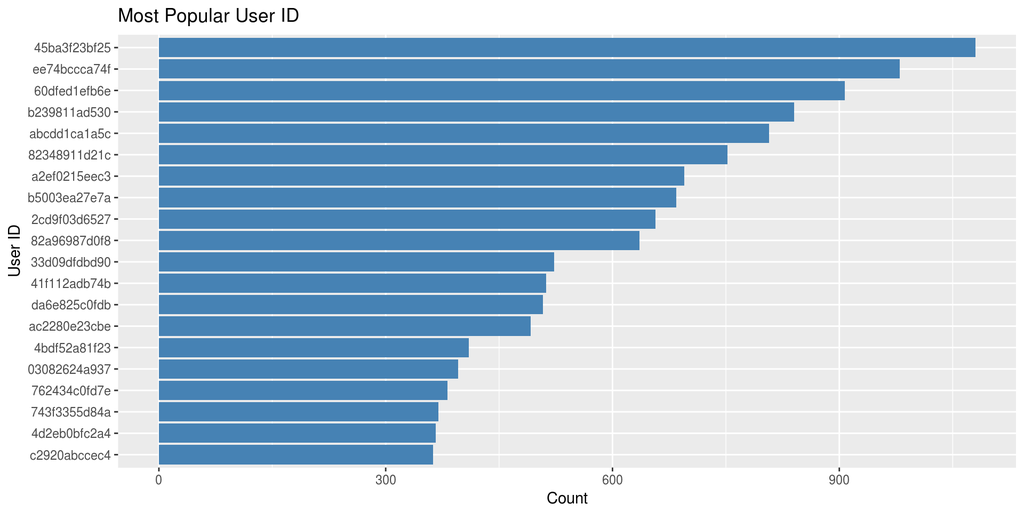

```r
avi %>% group_by(user_id) %>% summarise(Count=n()) %>%
  arrange(desc(Count)) %>% head(20) %>%
  ggplot(aes(x=reorder(user_id, Count), y=Count)) +
  geom_col(fill="steelblue") + coord_flip() +
  labs(x="User ID", y="Count", title = "Most Popular User ID")
```

## 5.3 region

### 5.3.1 in train

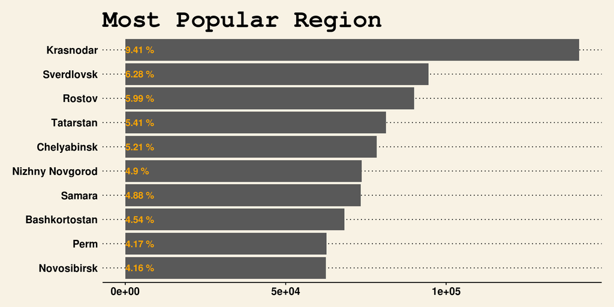

```r
region <- c("Краснодарский край","Свердловская область",
            "Ростовская область","Татарстан","Челябинская область",
            "Нижегородская область","Самарская область",
            "Башкортостан","Пермский край","Новосибирская область",
            "Ставропольский край","Ханты-Мансийский АО",
            "Воронежская область","Иркутская область",
            "Тульская область","Тюменская область","Белгородская область")
region_en <- c("Krasnodar","Sverdlovsk","Rostov","Tatarstan",
               "Chelyabinsk","Nizhny Novgorod","Samara",
               "Bashkortostan","Perm","Novosibirsk",
               "Stavropol","Khanty-Mansiysk Autonomous Okrug",
               "Voronezh","Irkutsk","Tula","Tyumen","Belgorod")

df_regions_en <- as.data.frame(cbind(region,region_en))

avi %>% group_by(region) %>% summarise(Count = n()) %>%
  arrange(desc(Count)) %>% head(10) %>% left_join(df_regions_en) %>%
  mutate(region_en = reorder(region_en, Count)) %>%
  ggplot(aes(x=region_en, y=Count)) +
  geom_col() + coord_flip() + theme_wsj() +
  geom_text(aes(x=region_en, y = 1, label=paste(round((Count/nrow(avi))*100,2), "%")),
            hjust = 0, vjust =.5,  fontface = 'bold', color="orange") +
  labs(x='region', y='count', title = 'Most Popular Region')
```

### 5.3.2 in test

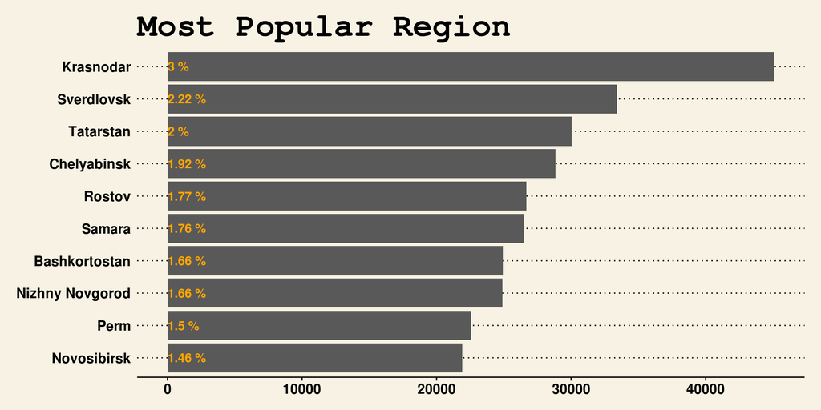

```r
avite %>% group_by(region) %>% summarise(Count = n()) %>%
  arrange(desc(Count)) %>% head(10) %>% left_join(df_regions_en) %>%
  mutate(region_en = reorder(region_en, Count)) %>%
  ggplot(aes(x=region_en, y=Count)) +
  geom_col() + coord_flip() + theme_wsj() +
  geom_text(aes(x=region_en, y = 1, label=paste(round((Count/nrow(avi))*100,2), "%")),
            hjust = 0, vjust =.5,  fontface = 'bold', color="orange") +
  labs(x='region', y='count', title = 'Most Popular Region')
```

### 5.3.3 Distribution of Deal Probablity

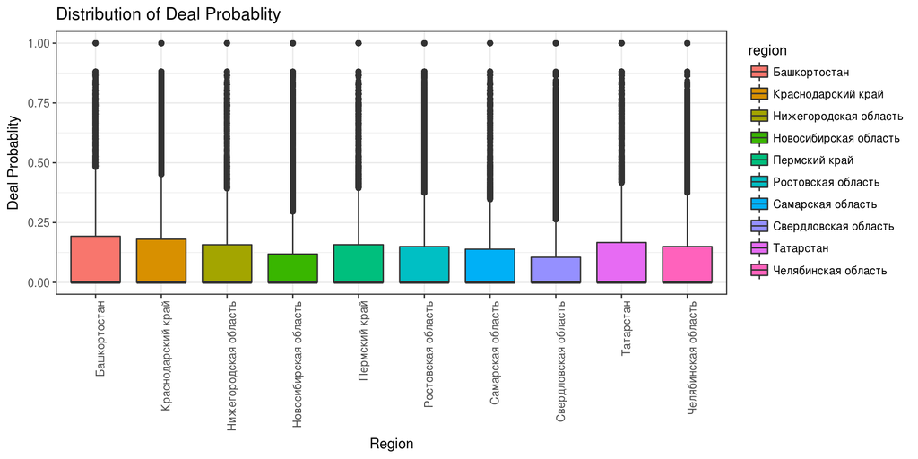

```r
region_dt <- avi %>% group_by(region) %>% summarise(Count = n()) %>%
  arrange(desc(Count)) %>% head(10)
avi %>% filter(region %in% region_dt$region) %>%
  ggplot(aes(x=factor(region), y=deal_probability, fill= region)) +
  geom_boxplot() + theme_bw() +
  labs(x='Region', y="Deal Probablity", title="Distribution of Deal Probablity") +
  theme(axis.text.x = element_text(angle=90, hjust = 1))
```

## 5.4 city

### 5.4.1 most popular city on Graph

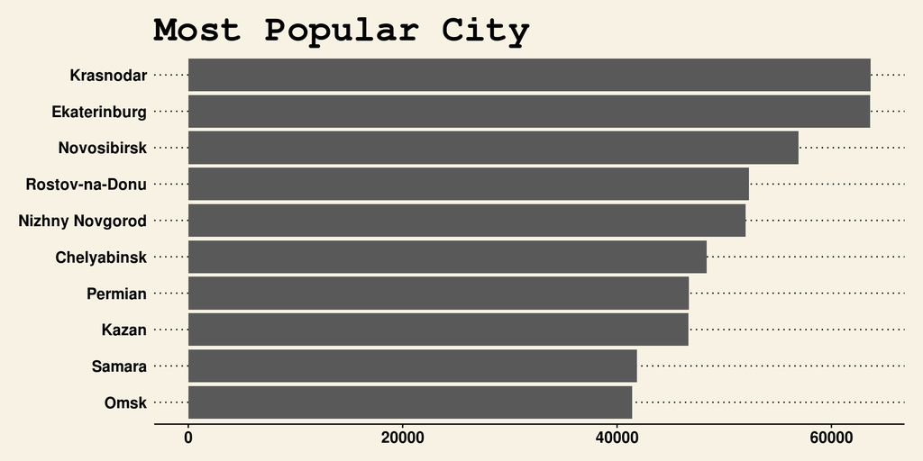

```r
city <-c("Краснодар","Екатеринбург","Новосибирск","Ростов-на-Дону","Нижний Новгород",
         "Челябинск","Пермь","Казань","Самара","Омск")

city_en <-c("Krasnodar","Ekaterinburg","Novosibirsk","Rostov-na-Donu",
            "Nizhny Novgorod", "Chelyabinsk","Permian","Kazan","Samara","Omsk")

df_city_en <- as.data.frame(cbind(city,city_en) )

avi %>% group_by(city) %>% summarise(Count = n()) %>%
  arrange(desc(Count)) %>% head(10) %>% left_join(df_city_en) %>%
  mutate(city_en = reorder(city_en, Count)) %>%
  ggplot(aes(x=city_en, y=Count)) +
  labs(x='City', y= 'Count', title = 'Most Popular City') +
  geom_col() + coord_flip() + theme_wsj()
```

### 5.4.2 most popular city on Data

```r
avi %>% group_by(city) %>% summarise(Count = n()) %>%
  arrange(desc(Count)) %>% head(10) %>% left_join(df_city_en) %>% datatable()
```

|  | city | Count | city_en |
| --- | --- | --- | --- |
| 1 | Краснодар | 63638 | Krasnodar |
| 2 | Екатеринбург | 63602 | Ekaterinburg |
| 3 | Новосибирск | 56929 | Novosibirsk |
| 4 | Ростов-на-Дону | 52323 | Rostov-na-Donu |
| 5 | Нижний Новгород | 52010 | Nizhny Novgorod |
| 6 | Челябинск | 48380 | Chelyabinsk |
| 7 | Пермь | 46720 | Permian |
| 8 | Казань | 46663 | Kazan |
| 9 | Самара | 41875 | Samara |
| 10 | Омск | 41412 | Omsk |

## 5.5 parent_category_name

### 5.5.1 Most popular Parent Category on Graph

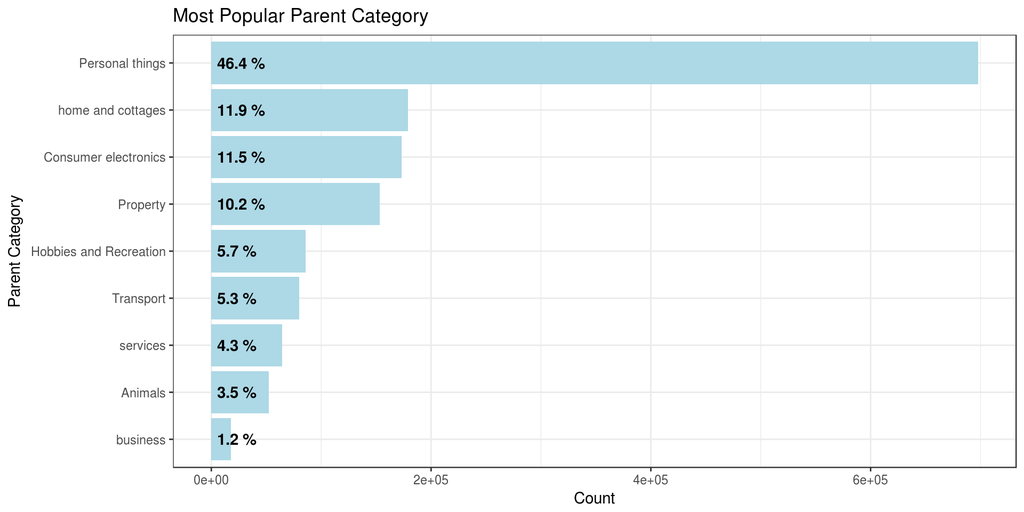

```r
parent_category_name <- c("Личные вещи","Для дома и дачи",
                          "Бытовая электроника","Недвижимость",
                          "Хобби и отдых","Транспорт",
                          "Услуги","Животные","Для бизнеса")

parent_category_name_en <- c("Personal things","home and cottages",
                             "Consumer electronics","Property",
                             "Hobbies and Recreation","Transport",
                             "services","Animals","business")

df_parentcategory_en <- as.data.frame(cbind(parent_category_name,parent_category_name_en ) )

avi %>% group_by(parent_category_name) %>% summarise(Count = n()) %>%
  left_join(df_parentcategory_en) %>% arrange(desc(Count)) %>%
  ggplot(aes(x=reorder(parent_category_name_en, Count), y=Count)) +
  geom_col(fill="lightblue") + coord_flip() + theme_bw() +
  labs(x="Parent Category", y="Count", title = "Most Popular Parent Category") +
  geom_text(aes(x=parent_category_name_en, y = 5000,
                label= paste(round(Count*100/nrow(avi),1), "%")  ),
            hjust=0, vjust =.5, fontface='bold')
```

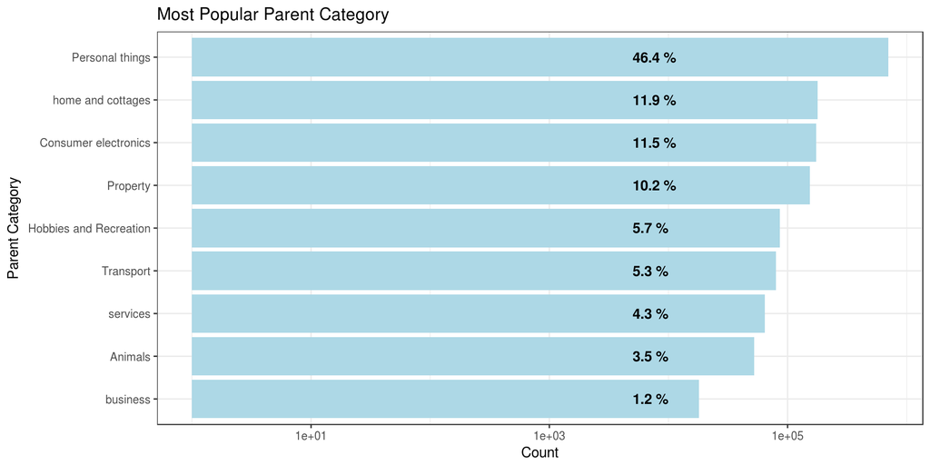

```r
avi %>% group_by(parent_category_name) %>% summarise(Count = n()) %>%
  left_join(df_parentcategory_en) %>% arrange(desc(Count)) %>%
  ggplot(aes(x=reorder(parent_category_name_en, Count), y=Count)) +
  geom_col(fill="lightblue") + coord_flip() + theme_bw() +
  labs(x="Parent Category", y="Count", title = "Most Popular Parent Category") +
  geom_text(aes(x=parent_category_name_en, y = 5000, label= paste(round(Count*100/nrow(avi),1), "%")  ),
            hjust=0, vjust =.5, fontface='bold') +scale_y_log10()
```

### 5.5.2 Most popular Parent Category on Data

```r
avi %>% group_by(parent_category_name) %>% summarise(Count = n()) %>%
  left_join(df_parentcategory_en) %>% arrange(desc(Count)) %>% datatable()
```

|  | parent_category_name | Count | parent_category_name_en |
| --- | --- | --- | --- |
| 1 | Личные вещи | 697623 | Personal things |
| 2 | Для дома и дачи | 178823 | home and cottages |
| 3 | Бытовая электроника | 173008 | Consumer electronics |
| 4 | Недвижимость | 153190 | Property |
| 5 | Хобби и отдых | 86011 | Hobbies and Recreation |
| 6 | Транспорт | 79839 | Transport |
| 7 | Услуги | 64385 | services |
| 8 | Животные | 52470 | Animals |
| 9 | Для бизнеса | 18075 | business |

## 5.6 category_name

### 5.6.1 Most Popular Category on Graph

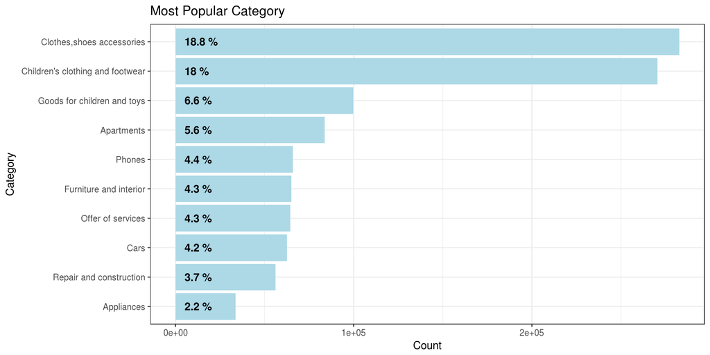

```r
category_name <- c("Одежда, обувь, аксессуары",
                   "Детская одежда и обувь",
                   "Товары для детей и игрушки",
                   "Квартиры",
                   "Телефоны",
                   "Мебель и интерьер",
                   "Предложение услуг",
                   "Автомобили",
                   "Ремонт и строительство",
                   "Бытовая техника",
                   "Недвижимость за рубежом",
                   "Дома, дачи, коттеджи",
                   "Земельные участки",
                   "Комнаты",
                   "Грузовики и спецтехника",
                   "Готовый бизнес",
                   "Гаражи и машиноместа",
                   "Коммерческая недвижимость")

category_name_en <- c("Clothes,shoes accessories" ,
                      "Children's clothing and footwear" ,
                      "Goods for children and toys" ,
                      "Apartments" ,
                      "Phones",
                      "Furniture and interior",
                      "Offer of services",
                      "Cars",
                      "Repair and construction",
                      "Appliances",
                      "Property Abroad",
                      "Houses, cottages, cottages",
                      "Land",
                      "Rooms",
                      "Trucks and special equipment",
                      "Ready business",
                      "Garages and parking places",
                      "Commercial Property")

df_category_en <- as.data.frame(cbind(category_name,category_name_en ) )

avi %>% group_by(category_name) %>% summarise(Count = n()) %>%
  arrange(desc(Count)) %>% head(10) %>% left_join(df_category_en) %>%
  ggplot(aes(x=reorder(category_name_en, Count), y=Count)) +
  geom_col(fill = "lightblue") + coord_flip() + theme_bw() +
  labs(x='Category', y='Count', title='Most Popular Category') +
  geom_text(aes(x=category_name_en, y= 5000,
                label= paste(round(Count*100/nrow(avi),1), "%")),
            hjust = 0, vjust=.5, fontface='bold')
```

### 5.6.2 Most Popular Category on Data

```r
avi %>% group_by(category_name) %>% summarise(Count = n()) %>%
  arrange(desc(Count)) %>% head(10) %>% left_join(df_category_en) %>% datatable()
```

|  | category_name | Count | category_name_en |
| --- | --- | --- | --- |
| 1 | Одежда, обувь, аксессуары | 282753 | Clothes,shoes accessories |
| 2 | Детская одежда и обувь | 270359 | Children's clothing and footwear |
| 3 | Товары для детей и игрушки | 99747 | Goods for children and toys |
| 4 | Квартиры | 83670 | Apartments |
| 5 | Телефоны | 65944 | Phones |
| 6 | Мебель и интерьер | 65035 | Furniture and interior |
| 7 | Предложение услуг | 64385 | Offer of services |
| 8 | Автомобили | 62494 | Cars |
| 9 | Ремонт и строительство | 56201 | Repair and construction |
| 10 | Бытовая техника | 33705 | Appliances |

## 5.7 param_1

### 5.7.1 Most Popular param_1 on Graph

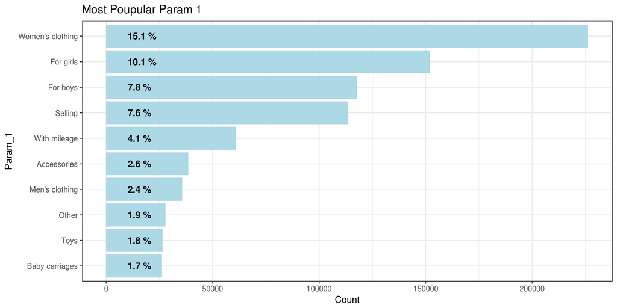

```r
param_1 <- c("Женская одежда","Для девочек","Для мальчиков",
             "Продам","С пробегом","Аксессуары",
             "Мужская одежда","Другое",
             "Игрушки","Детские коляски")

param_1_en <- c("Women's clothing","For girls","For boys",
                "Selling","With mileage","Accessories","Men's clothing","Other",
                "Toys","Baby carriages")

df_param_1_en <- as.data.frame(cbind(param_1,param_1_en ) )

avi %>% filter(!is.na(param_1)) %>% group_by(param_1) %>%
  summarise(Count = n()) %>% arrange(desc(Count)) %>% head(10) %>%
  left_join(df_param_1_en) %>%
  ggplot(aes(x = reorder(param_1_en, Count), y= Count)) +
  geom_col(fill='lightblue') + coord_flip() + theme_bw() +
  labs(x = 'Param_1', y = 'Count', title = 'Most Poupular Param 1') +
  geom_text(aes(x=param_1_en, y = 10000,
                label = paste(round(Count*100/nrow(avi),1), "%")),
            hjust=0, vjust=.5, fontface='bold')
```

### 5.7.2 Most Popular param_1 on DT

```r
avi %>% filter(!is.na(param_1)) %>% group_by(param_1) %>%
  summarise(Count = n()) %>% arrange(desc(Count)) %>% head(10) %>%
  left_join(df_param_1_en) %>% datatable()
```

|  | param_1 | Count | param_1_en |
| --- | --- | --- | --- |
| 1 | Женская одежда | 226289 | Women's clothing |
| 2 | Для девочек | 151979 | For girls |
| 3 | Для мальчиков | 117772 | For boys |
| 4 | Продам | 113764 | Selling |
| 5 | С пробегом | 61024 | With mileage |
| 6 | Аксессуары | 38568 | Accessories |
| 7 | Мужская одежда | 35716 | Men's clothing |
| 8 | Другое | 27874 | Other |
| 9 | Игрушки | 26442 | Toys |
| 10 | Детские коляски | 26248 | Baby carriages |

## 5.8 param_2

### 5.8.1 Most Popular param_2 on Graph

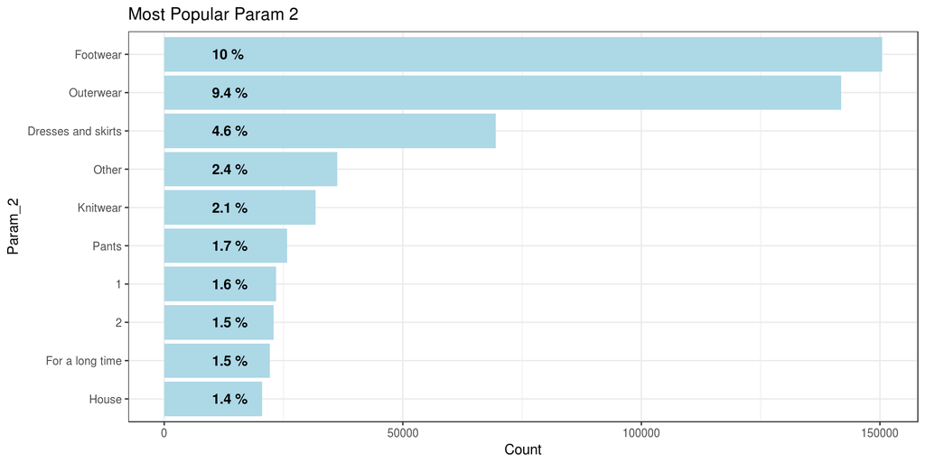

```r
param_2 <- c("Обувь","Верхняя одежда",
             "Платья и юбки","Другое",
             "Трикотаж","Брюки",
             "1","2","На длительный срок","Дом")

param_2_en <- c("Footwear","Outerwear","Dresses and skirts","Other",
                "Knitwear","Pants","1","2","For a long time","House")

df_param_2_en <- as.data.frame(cbind(param_2,param_2_en ) )

avi %>% filter(!is.na(param_2)) %>% group_by(param_2) %>%
  summarise(Count = n()) %>% arrange(desc(Count)) %>% head(10) %>%
  left_join(df_param_2_en) %>%
  ggplot(aes(x=reorder(param_2_en, Count), y = Count)) +
  geom_col(fill='lightblue') + coord_flip() + theme_bw() +
  labs(x='Param_2', y='Count', title='Most Popular Param 2') +
  geom_text(aes(x=param_2_en, y=10000,
                label = paste(round(Count*100/nrow(avi),1), "%")),
            hjust = 0, vjust=.5, fontface = 'bold')
```

### 5.8.2 Most Popular param_2 on DT

```r
avi %>% filter(!is.na(param_2)) %>% group_by(param_2) %>%
  summarise(Count = n()) %>% arrange(desc(Count)) %>% head(10) %>%
  left_join(df_param_2_en) %>% datatable()
```

|  | param_2 | Count | param_2_en |
| --- | --- | --- | --- |
| 1 | Обувь | 150450 | Footwear |
| 2 | Верхняя одежда | 141860 | Outerwear |
| 3 | Платья и юбки | 69483 | Dresses and skirts |
| 4 | Другое | 36284 | Other |
| 5 | Трикотаж | 31684 | Knitwear |
| 6 | Брюки | 25807 | Pants |
| 7 | 1 | 23426 | 1 |
| 8 | 2 | 22921 | 2 |
| 9 | На длительный срок | 22096 | For a long time |
| 10 | Дом | 20550 | House |

## 5.9 param_3

### 5.9.1 Most Popular param_3 on Graph

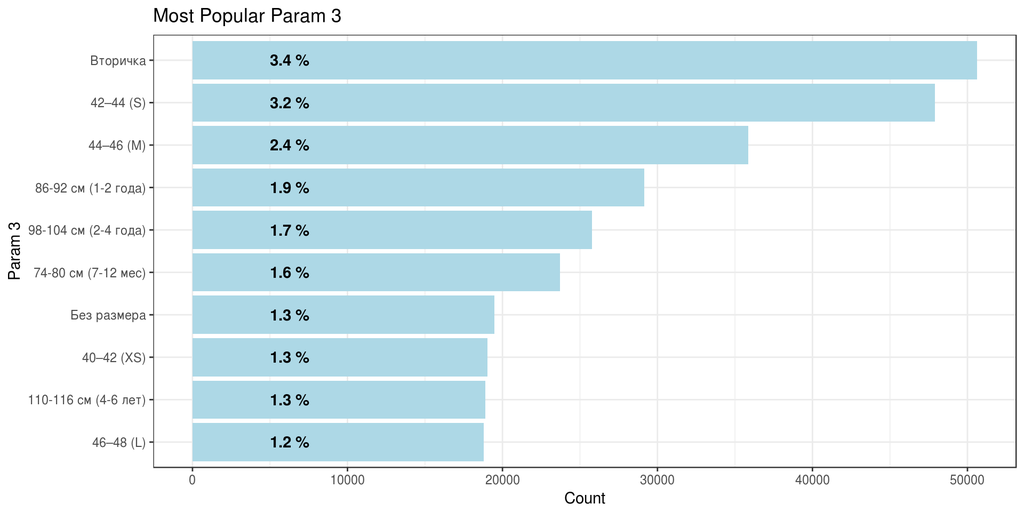

```r
avi %>% filter(!is.na(param_3)) %>% group_by(param_3) %>%
  summarise(Count = n()) %>% arrange(desc(Count)) %>% head(10) %>%
  ggplot(aes(x=reorder(param_3, Count), y=Count)) +
  geom_col(fill='lightblue') + coord_flip() + theme_bw() +
  labs(x='Param 3', y='Count', title='Most Popular Param 3') +
  geom_text(aes(x=param_3, y=5000,
                label = paste(round(Count*100/nrow(avi),1) , "%")),
            hjust=0, vjust=.5, fontface='bold')
```

### 5.9.2 Most Popular param_3 on DT

```r
avi %>% filter(!is.na(param_3)) %>% group_by(param_3) %>%
  summarise(Count = n()) %>% arrange(desc(Count)) %>% head(10) %>% datatable()
```

|  | param_3 | Count |
| --- | --- | --- |
| 1 | Вторичка | 50615 |
| 2 | 42–44 (S) | 47915 |
| 3 | 44–46 (M) | 35854 |
| 4 | 86-92 см (1-2 года) | 29139 |
| 5 | 98-104 см (2-4 года) | 25774 |
| 6 | 74-80 см (7-12 мес) | 23708 |
| 7 | Без размера | 19494 |
| 8 | 40–42 (XS) | 19041 |
| 9 | 110-116 см (4-6 лет) | 18896 |
| 10 | 46–48 (L) | 18783 |

## 5.10 title

Memory Limits Problem on Windows

### 5.10.1 Most Popular Title on Graph

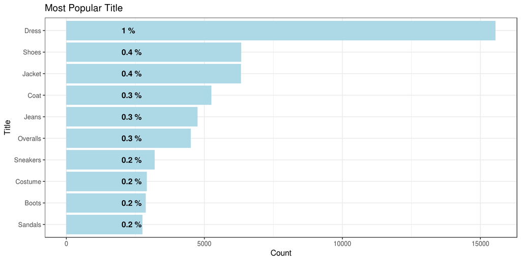

```r
title <- c("Платье","Туфли","Куртка",
           "Пальто","Джинсы","Комбинезон",
           "Кроссовки","Костюм","Ботинки",
           "Босоножки")

title_en <- c("Dress","Shoes","Jacket",
              "Coat","Jeans","Overalls",
              "Sneakers","Costume","Boots",
              "Sandals")

df_title_en <- as.data.frame(cbind(title,title_en) )

avi %>% group_by(title) %>% summarise(Count=n()) %>%
  arrange(desc(Count)) %>% head(10) %>% left_join(df_title_en) %>%
  ggplot(aes(x=reorder(title_en, Count), y=Count)) +
  geom_col(fill='lightblue') + coord_flip() + theme_bw() +
  labs(x='Title', y='Count', title='Most Popular Title') +
  geom_text(aes(x=title_en, y=2000,
                label = paste(round(Count*100/nrow(avi),1) , "%")),
            hjust=0, vjust=.5, fontface='bold')
```

### 5.10.2 Most Popular Title on DT

```r
avi %>% group_by(title) %>% summarise(Count=n()) %>%
  arrange(desc(Count)) %>% head(10) %>% left_join(df_title_en) %>% kable()
```

[output not shown]

### 5.10.3 Title Length

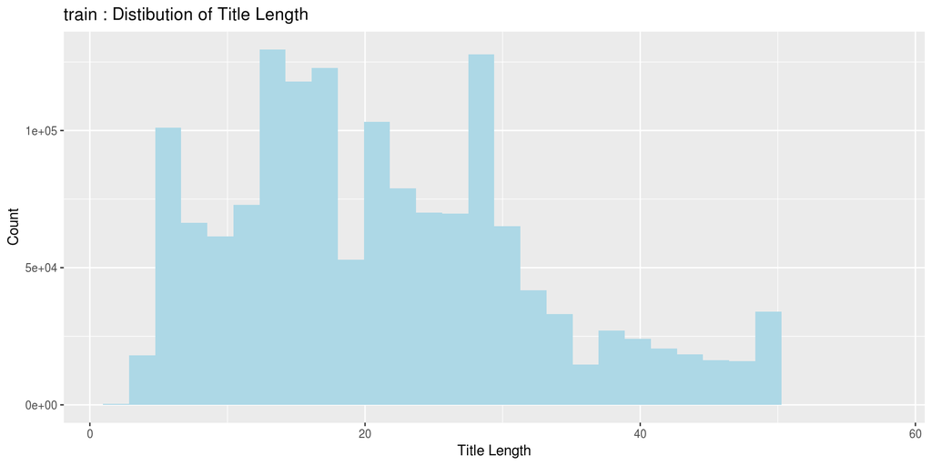

```r
avi %>% mutate(title_len = str_count(title)) %>%
  ggplot(aes(x=title_len)) + geom_histogram(bins = 30, fill='lightblue') +
  labs(x='Title Length', y='Count', title='train : Distibution of Title Length')
```

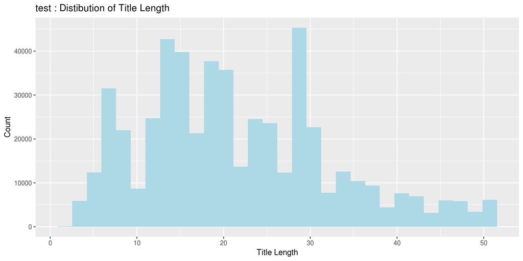

```r
avite %>% mutate(title_len = str_count(title)) %>%
  ggplot(aes(x=title_len)) + geom_histogram(bins = 30, fill='lightblue') +
  labs(x='Title Length', y='Count', title='test : Distibution of Title Length')
```

## 5.11 description

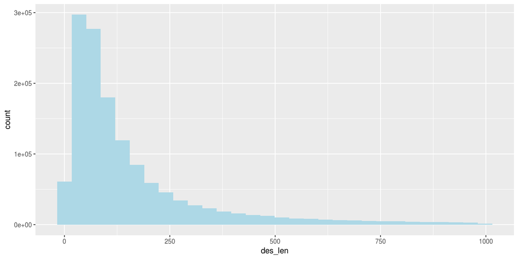

```r
avi %>% mutate(des_len = str_count(description)) %>%
  filter(des_len < 1000) %>%
  ggplot(aes(x=des_len)) + geom_histogram(bins=30, fill = 'lightblue')
```

## 5.12 price

### 5.12.1 Basic & Log

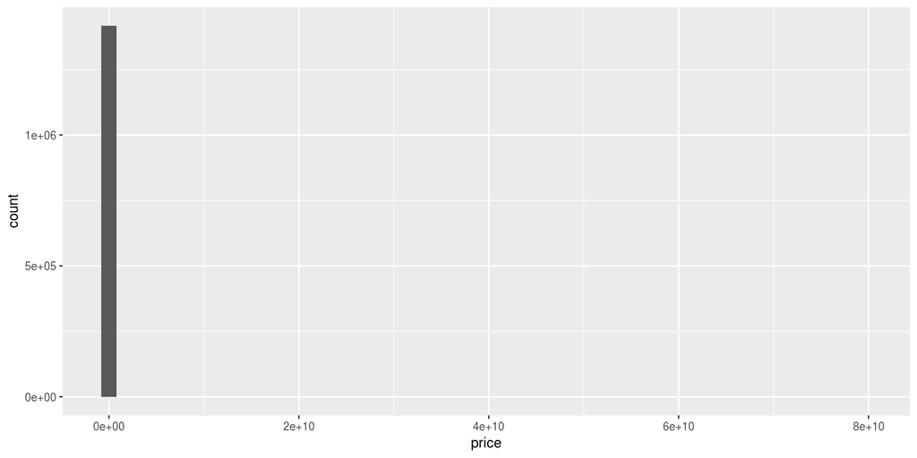

```r
avi %>% filter(!is.na(price)) %>% ggplot(aes(x=price)) + geom_histogram(bins=50)
```

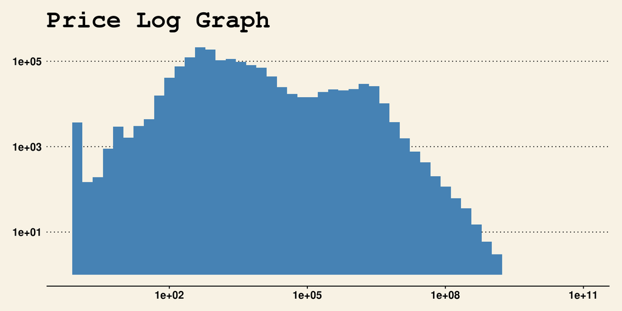

```r
avi %>% filter(!is.na(price)) %>% ggplot(aes(x=price)) +
  geom_histogram(bins=50, fill = 'steelblue')  +
  labs(title="Price Log Graph") +
  scale_x_log10() + scale_y_log10() + theme_wsj()
```

### 5.12.2 with UserType

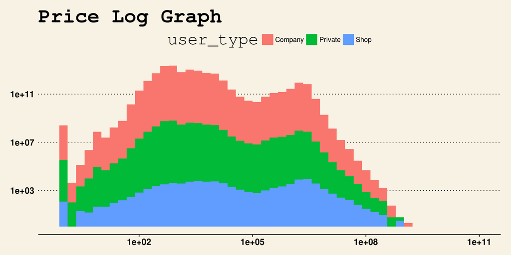

```r
avi %>% filter(!is.na(price)) %>% ggplot(aes(x=price, fill=user_type)) +
  geom_histogram(bins=50)  +
  labs(x='price', y='count', title="Price Log Graph") +
  scale_x_log10() + scale_y_log10() + theme_wsj()
```

### 5.12.3 with Parent Category

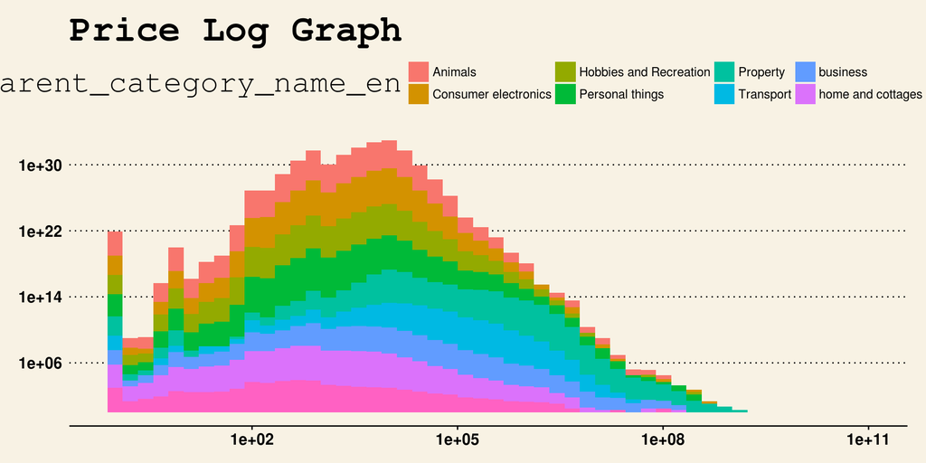

```r
avi %>% filter(!is.na(price)) %>% left_join(df_parentcategory_en) %>%
  ggplot(aes(x=price, fill=parent_category_name_en)) +
  geom_histogram(bins=50)  +
  labs(x='price', y='count', title="Price Log Graph") +
  scale_x_log10() + scale_y_log10() + theme_wsj()
```

## 5.13 item_seq_number

### 5.13.1 Basic & Log

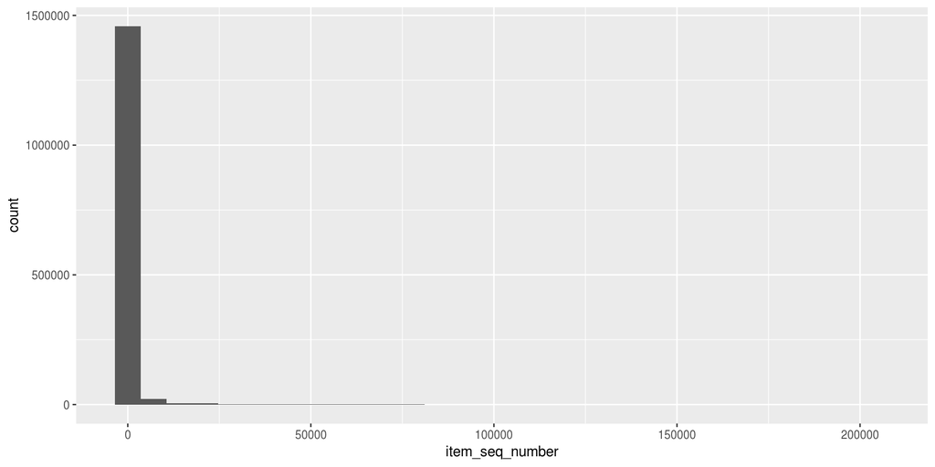

```r
avi %>% ggplot(aes(x=item_seq_number)) + geom_histogram(bins = 30)
```

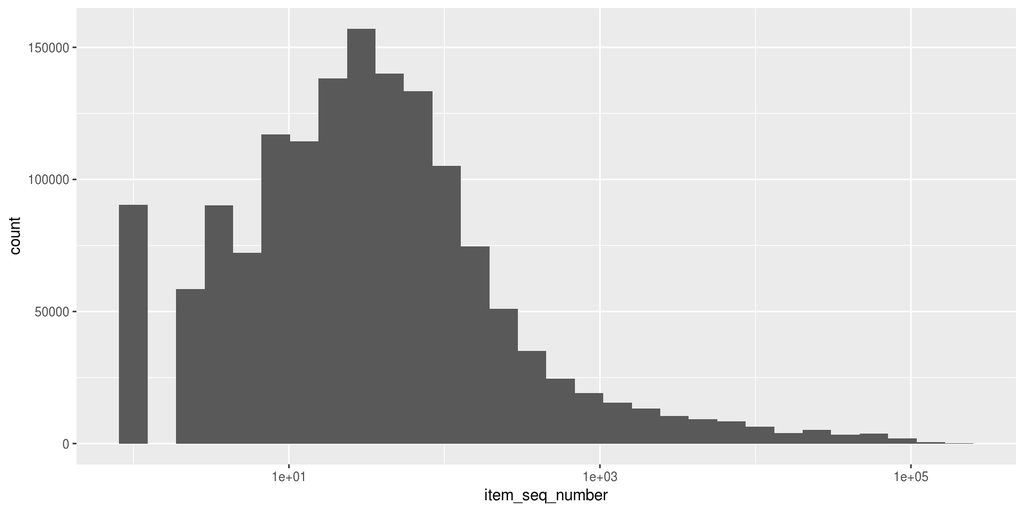

```r
avi %>% ggplot(aes(x=item_seq_number)) +
  geom_histogram(bins = 30) + scale_x_log10()
```

### 5.13.2 with User Type

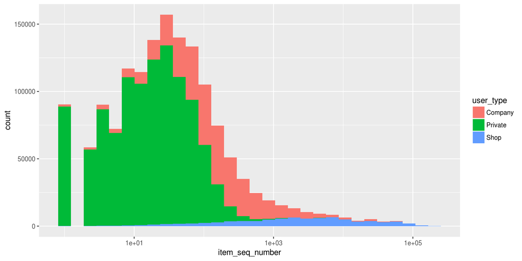

```r
avi %>% ggplot(aes(x=item_seq_number, fill=user_type)) +
  geom_histogram(bins = 30) + scale_x_log10()
```

## 5.14 activation_date

### 5.14.1 Graph

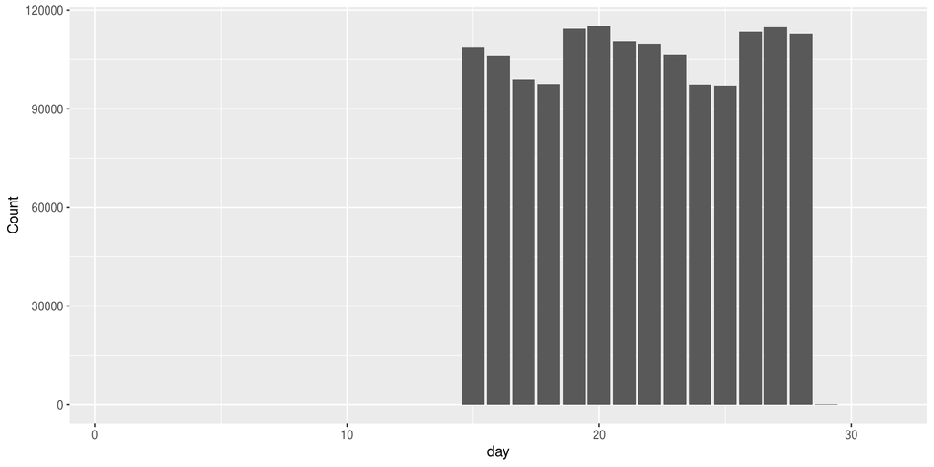

```r
avi %>% mutate(day = day(activation_date)) %>% group_by(day) %>%
  summarise(Count = n()) %>%
  ggplot(aes(x=day, y=Count)) + geom_col()
```

### 5.14.2 train DT

```r
avi %>% mutate(day = day(activation_date)) %>% group_by(day) %>%
  summarise(Count = n()) %>%
  datatable(filter = "top", options = list(pageLength = 30, autoWidth= T))
```

|  | day | Count |
| --- | --- | --- |
| 1 | 1 | 3 |
| 2 | 2 | 3 |
| 3 | 3 | 2 |
| 4 | 7 | 1 |
| 5 | 15 | 108615 |
| 6 | 16 | 106168 |
| 7 | 17 | 98773 |
| 8 | 18 | 97554 |
| 9 | 19 | 114416 |
| 10 | 20 | 115190 |

[output cut: 11 more lines]

### test DT

```r
avite %>% mutate(day = day(activation_date)) %>% group_by(day) %>%
  summarise(Count = n()) %>%
  datatable(filter = "top", options = list(pageLength = 30, autoWidth= T))
```

|  | day | Count |
| --- | --- | --- |
| 1 | 12 | 81824 |
| 2 | 13 | 77176 |
| 3 | 14 | 70366 |
| 4 | 15 | 58793 |
| 5 | 16 | 58909 |
| 6 | 17 | 80191 |
| 7 | 18 | 81114 |
| 8 | 19 | 64 |
| 9 | 20 | 1 |

### 5.14.3 weekday

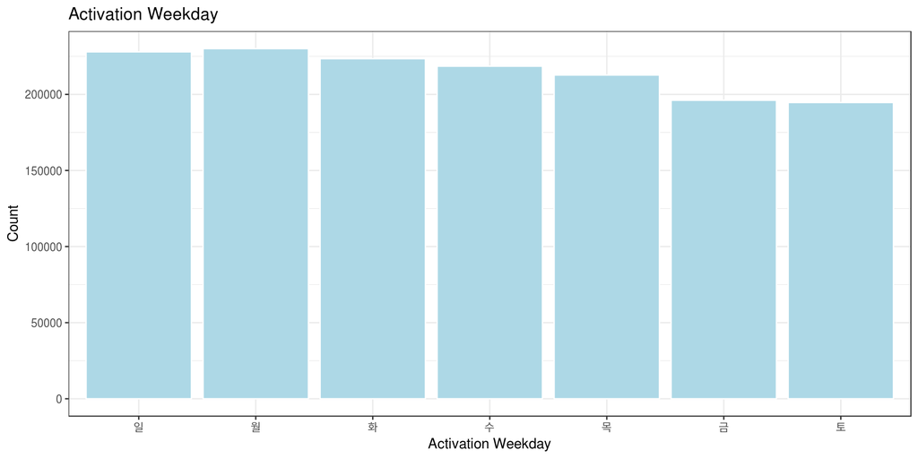

```r
avi %>% mutate(wday = wday(activation_date, labe=T, locale="UK")) %>%
  group_by(wday) %>% summarise(Count=n()) %>%
  ggplot(aes(x=wday, y=Count)) +
  geom_col(fill='lightblue', col='white') + theme_bw() +
  labs(x="Activation Weekday", y="Count", title="Activation Weekday")
```

## 5.15 user_type

### 5.15.1 on train

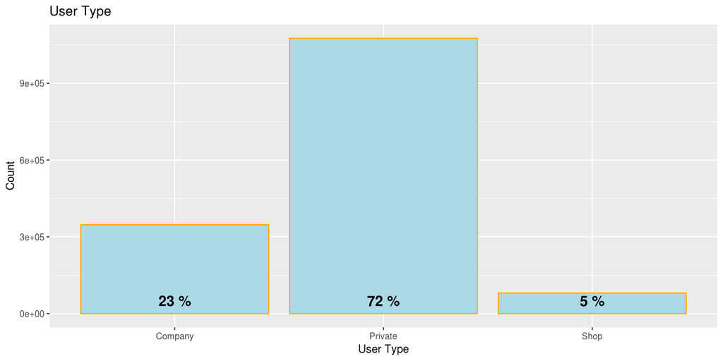

```r
avi %>% group_by(user_type) %>% summarise(Count = n()) %>%
  ggplot(aes(x=user_type, y=Count)) +
  geom_col(color='orange', fill = 'lightblue') +
  labs(x='User Type', y='Count', title = 'User Type') +
  geom_text(aes(x=user_type, y= 50000,
                label = paste(round(Count*100/nrow(avi)), "%")),
            size = 5, fontface='bold')
```

### 5.15.2 on test

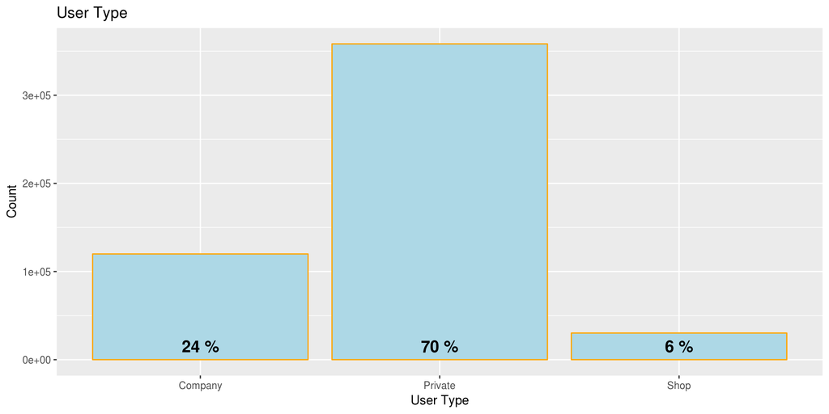

```r
avite %>% group_by(user_type) %>% summarise(Count = n()) %>%
  ggplot(aes(x=user_type, y=Count)) +
  geom_col(color='orange', fill = 'lightblue') +
  labs(x='User Type', y='Count', title = 'User Type') +
  geom_text(aes(x=user_type, y= 15000,
                label = paste(round(Count*100/nrow(avite)), "%")),
            size = 5, fontface='bold')
```

## 5.16 image

### 5.16.1 image on train

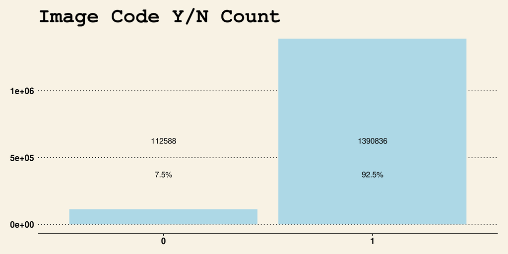

```r
avi$image_codeYN <- ifelse(is.na(avi$image), 0, 1)

avi %>% group_by(image_codeYN) %>% summarise(Count = n()) %>%
  ggplot(aes(x=factor(image_codeYN), y=Count)) +
  geom_col(fill='lightblue') + theme_wsj() +
  labs(x="image_codeYN", y="Count", title="Image Code Y/N Count") +
  geom_text(aes(x=factor(image_codeYN), y=500000,
                label= paste0(Count, "\n\n\n",
                              round(Count*100/nrow(avi),1), "%")))
```

### 5.16.2 image on test

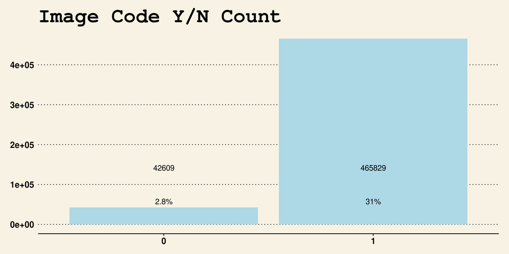

```r
avite$image_codeYN <- ifelse(is.na(avite$image), 0, 1)
avite %>% group_by(image_codeYN) %>% summarise(Count = n()) %>%
  ggplot(aes(x=factor(image_codeYN), y=Count)) +
  geom_col(fill='lightblue') + theme_wsj() +
  labs(x="image_codeYN", y="Count", title="Image Code Y/N Count") +
  geom_text(aes(x=factor(image_codeYN), y=100000,
                label= paste0(Count, "\n\n\n",
                              round(Count*100/nrow(avi),1), "%")))
```

### 5.16.3 with Deal Probability

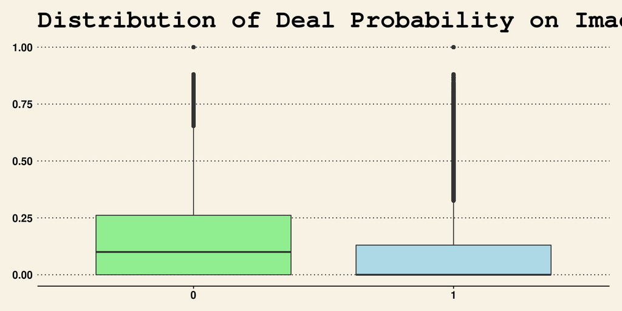

```r
ggplot(data=avi, aes(x=factor(image_codeYN), y=deal_probability)) +
  geom_boxplot(fill=c("lightgreen", "lightblue")) + theme_wsj() +
  labs(x="image_codeYN", y="Deal Probability",
       title = "Distribution of Deal Probability on ImageCode")
```

## 5.17 image_top_1

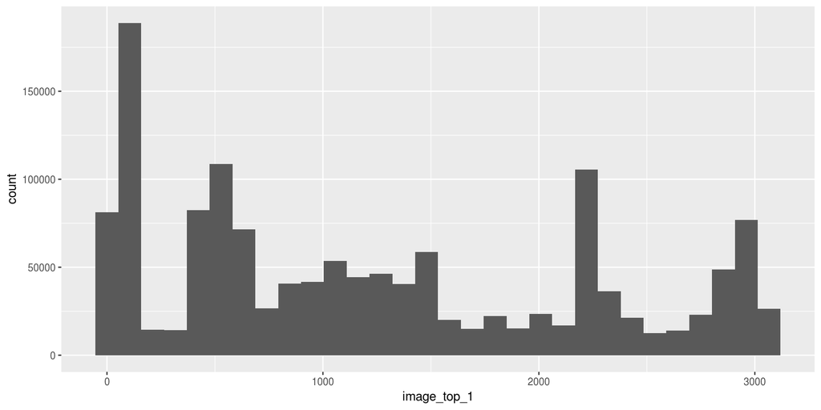

```r
ggplot(avi, aes(x=image_top_1)) + geom_histogram(bins = 30)
```